# Dutch School Example

Jeremy Foote

3/24/2020

## Example

I’m doing an in-depth example, primarily to give you examples of the sorts of things that you could do with the data, and so you’ll have code to work with.

This is above and beyond what I would expect for this week’s assignment, but I would love to see people be ambitious in how they approach it.

## My question

Do stronger friendships influence each other more?

While these are friendships ties, they are not all reciprocal Sometimes A nominates B as a friend, but B doesn’t nominate A. We might expect that when an edge is reciprocal (both people nominate each other), then the friendship is stronger, and therefore their behavior is more likely to be the same.

So, I want to find out if that’s true. My goal is to highlight drinking behavior and reciprocal ties.

First, I color the reciprocal ties. The `which_mutual()` function tells me which edges are reciprocal, and I make them a different color.

```r
library(igraph)
load(url('https://github.com/jdfoote/Communication-and-Social-Networks/raw/master/activities/school_graph.Rdata'))

which_mutual(friend_net)
```

```
##   [1]  TRUE  TRUE  TRUE FALSE  TRUE  TRUE FALSE  TRUE  TRUE FALSE  TRUE  TRUE
##  [13]  TRUE FALSE FALSE  TRUE FALSE FALSE FALSE FALSE  TRUE  TRUE  TRUE FALSE
##  [25]  TRUE FALSE  TRUE  TRUE  TRUE FALSE  TRUE  TRUE  TRUE  TRUE  TRUE  TRUE
##  [37]  TRUE FALSE FALSE  TRUE FALSE  TRUE  TRUE  TRUE  TRUE FALSE FALSE FALSE
##  [49]  TRUE  TRUE  TRUE  TRUE  TRUE  TRUE FALSE FALSE  TRUE  TRUE FALSE FALSE
##  [61] FALSE FALSE FALSE FALSE FALSE  TRUE FALSE FALSE FALSE  TRUE  TRUE  TRUE
##  [73]  TRUE FALSE  TRUE  TRUE  TRUE  TRUE  TRUE  TRUE  TRUE  TRUE FALSE  TRUE
##  [85] FALSE FALSE FALSE FALSE  TRUE FALSE  TRUE FALSE FALSE  TRUE  TRUE  TRUE
##  [97]  TRUE  TRUE  TRUE  TRUE FALSE  TRUE FALSE FALSE FALSE  TRUE  TRUE FALSE
## [109] FALSE FALSE FALSE FALSE FALSE  TRUE FALSE FALSE  TRUE
```

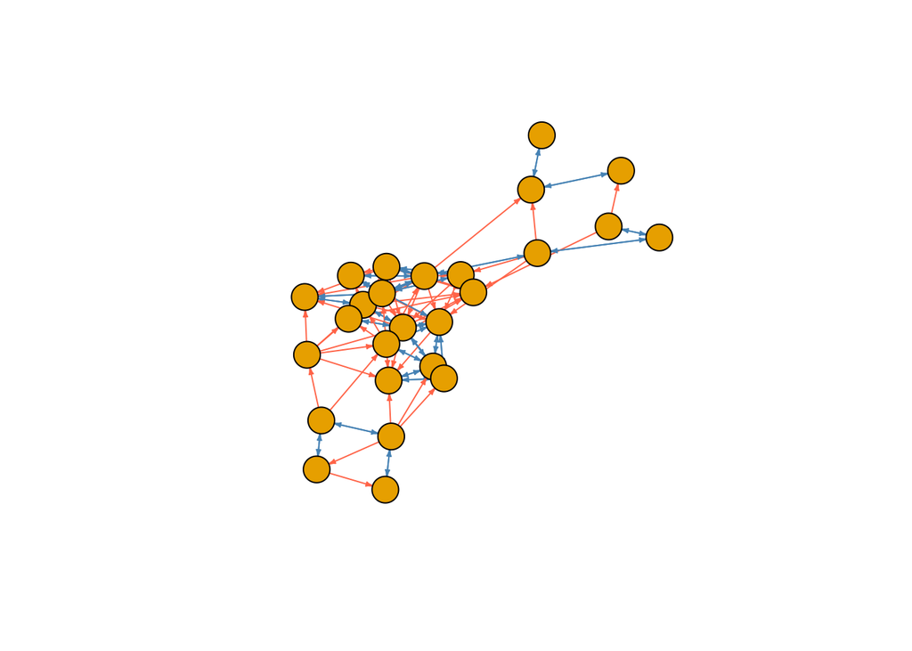

```r
E(friend_net)[which_mutual(friend_net)==F]$color = 'tomato'
E(friend_net)[which_mutual(friend_net)==T]$color = 'steelblue'
E(friend_net)$arrow.size = .25 # Setting the arrow size much smaller
V(friend_net)$label = NA # Removing the labels since they are meaningless
plot(friend_net)
```

Now, I want to add colors for drinking behavior to the vertices.

```r
# Make a list of colors
# This gives us a function that will produce a set of colors from light blue to dark blue
colors_func = colorRampPalette(c("lightblue","darkblue"))
# But we need to figure out how many colors we need.
# We'll make one color for each unique item in alcohol_use.
# If we look at it, we can see how many there are.
vertex.attributes(friend_net)$alcohol_use
```

```
##  [1]  4  2  1  1  1  1  3  1  3  2  2  5  3  3  1 NA  1  1 NA  2 NA  1 NA  1  1
## [26]  2
```

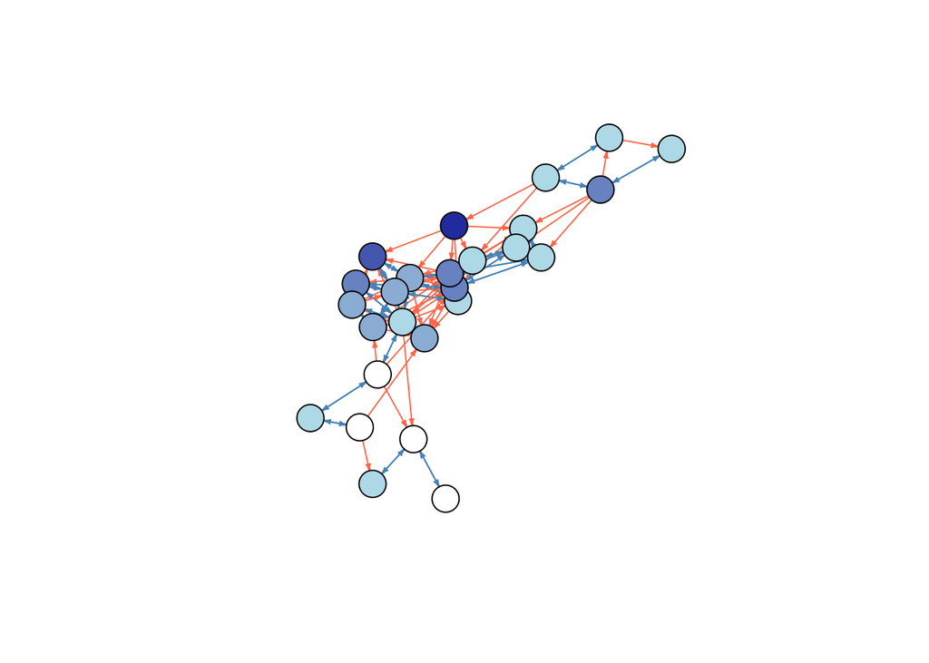

```r
# It looks like alcohol_use goes from 1 to 5, which is perfect.
# We can just use the values as an index to the colors list.
# First, we make the colors list - this will make 5 different colors,
# going from light to dark blue
color_list = colors_func(length(unique(V(friend_net)$alcohol_use)))
# Next, we set the colors of the nodes based on alcohol_use
V(friend_net)$color = color_list[V(friend_net)$alcohol_use]
plot(friend_net)
```

This is a pretty good plot, and helps us to get information about the question we were asking. One surprising finding is that there are a lot of non-mutual edges. Lots of people considered the other person a friend, but not vice versa. There isn’t clear evidence from this plot that mutual friends are more likely to have similar behavior, but we can try to draw that out a bit.

First, we can create plots that are a subset. The following plots show only reciprocal or non-reciprocal edges.

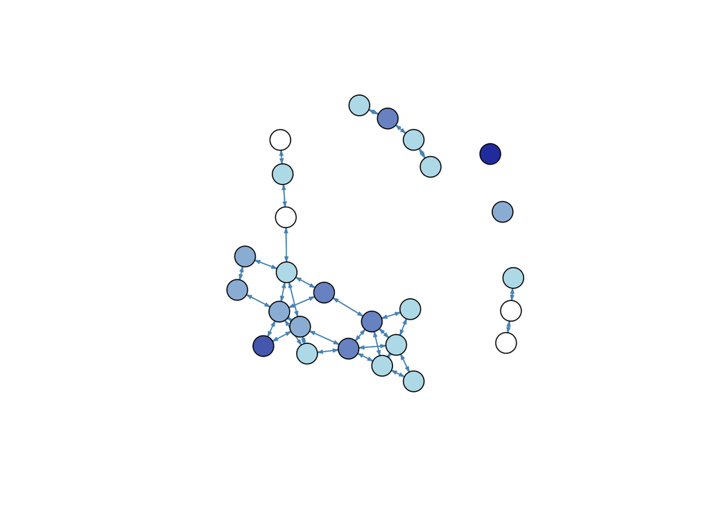

```r
recip = delete_edges(friend_net, E(friend_net)[which_mutual(friend_net)==F])
non_recip = delete_edges(friend_net, E(friend_net)[which_mutual(friend_net)==T])
plot(recip)
```

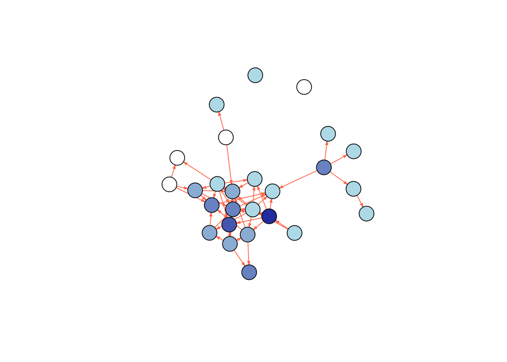

```r
plot(non_recip)
```

Finally, if you really wanted to get fancy, you could try to plot information about the relationship between tie type and similarity in behavior.

I’m doing this based on the answer to a question that I asked on Stack Overflow [here](https://stackoverflow.com/questions/60817618/how-do-you-color-the-edges-of-a-graph-based-on-whether-they-are-homophilous-in-i/60818946#60818946), which uses the `tidygraph` library.

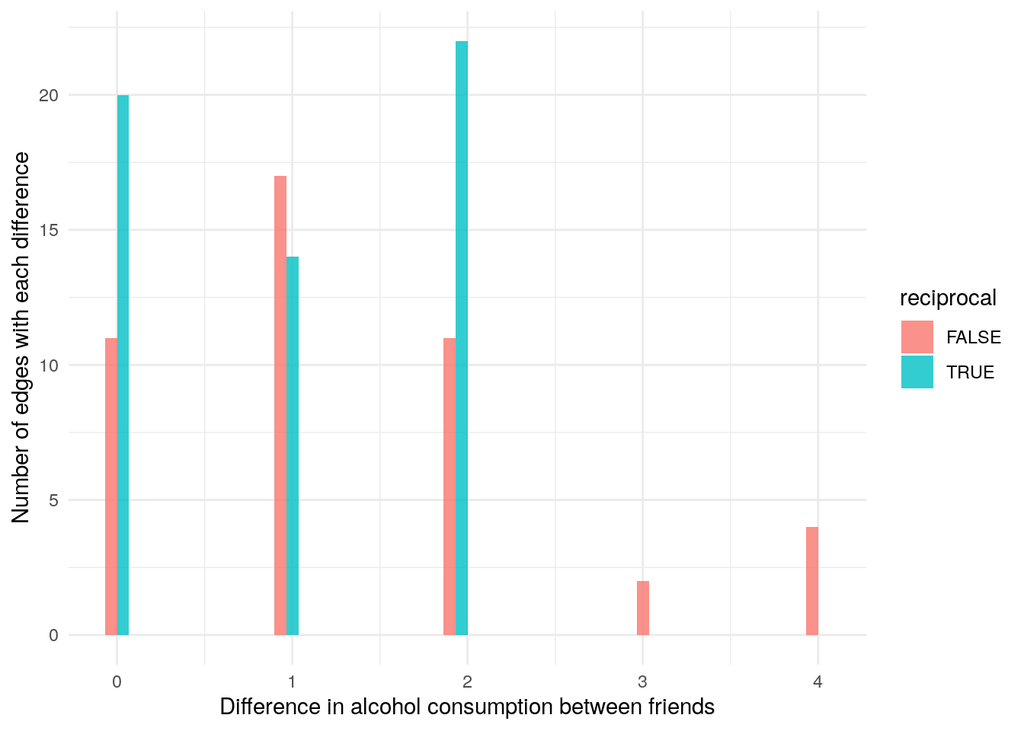

```r
# Uncomment the following line and run it one time if you need to install tidygraph
# install.packages('tidygraph')
library(tidygraph)
library(ggplot2)

# The following code creates 2 new edge attributes. The first is 'difference', which is the
# absolute value difference in alcohol_use from the two nodes of each edge
# The second is 'reciprocal', which just says if an edge is reciprocal. We already
# figured this out when we colored the edges, so I just use the color attribute
friend_net = friend_net %>%
  as_tbl_graph() %>%
  activate(edges) %>%
  mutate(difference = abs(.N()$alcohol_use[from] - .N()$alcohol_use[to]),
         reciprocal = color=='steelblue'
         )

# Next, we get the edges into a dataframe, so that we can analyze it

df = as.data.frame(edge.attributes(friend_net))

# Next, I'm going to plot the distribution of difference for reciprocal and non-reciprocal edges

df %>%
  ggplot(aes(x=difference, fill=reciprocal)) +
  geom_histogram(alpha=0.8, position="dodge") + theme_minimal() +
  xlab('Difference in alcohol consumption between friends') +
  ylab('Number of edges with each difference')
```

This last analysis is far beyond anything that we have done in class, but the example code might give you some hints about how you could do something similar.